# Team_Project

Taylor Wang, Ava Zhang, Joseph Henri Dionne

3/9/2023

##### Motivation for Our Question

###### The COVID-19 Pandemic affected nearly every facet of daily life from testing the durability of healthcare networks and supply chains around the world to altering how and where we live and work. However, COVID-19’s impact has potentially been the most pronounced. As the world began lockdowns, most people couldn’t work, healthcare systems were strained, and, most important to this presentation, global supply chains broke down causing contractions in the global economy by 3.1% in 2020 compared to the 2.9% growth experienced in 2019 according to the American Enterprise Institute, putting global profit losses in the billions of dollars. This begs the question, how has Tesla, an electric vehicle manufacturer which heavily relies on the global supply chain, performed in Pre-COVID, COVID, and Post-COVID periods? Answering this question will shed light on the effects of a global health crisis on a global manufacturer while providing other companies insight into how to successfully grow while navigating the complicated challenges of a global shutdown as a result of a global pandemic.

##### Introduction: Analysis of the economic trend of different companies throughout COVID-19

###### COVID-19 has no doubt influenced the entire world significantly and fundamentally in terms of social and economical development. This project aims at analyzing the economic trend of different companies throughout COVID-19 with focus on some specific companies. We aim to quantify the influences brought by COVID-19 by examining the performance of companies in terms of their closing prices.

###### After carefully looking into the background information, we decided to use the Adjusted Closing prices, along with some other indicators, in horizontal comparison.

##### Background Information (Cite from https://www.investopedia.com)

###### The closing price is the raw price or cash value of the last transacted price in a security before the market officially closes for normal trading. The closing price is considered the most accurate valuation of a stock or other security until trading resumes on the next trading day. The closing price on one day can be compared to the closing price on the previous day, 30 days earlier or a year earlier, to measure the changes in market sentiment toward that stock.

###### The closing price of any company’s stock will not usually reflect any news released by the company that day. Major company announcements related to earnings, stock splits, reverse stock splits, and stock dividends are typically released after the close of the regular trading day in order to give traders a chance to digest the news before acting upon it.

###### Tesla, Inc. is a pioneering American electric vehicle and clean energy company that has revolutionized the automotive industry. With its cutting-edge technology, market leadership in electric vehicles, focus on sustainable energy solutions, and impressive financial performance, analyzing Tesla’s performance during the COVID-19 period provides valuable insights into its resilience, adaptability, the impact of the pandemic on the automotive industry, and the growing demand for electric vehicles.

##### Libraries

```r
library(tidyverse)
```

```r
library(ggplot2)
```

##### Part I: Is Tesla different?

##### We are going to conduct a multivariate analysis with the below variables:

###### treatment (X): number of days / months (numerical)

###### outcome (Y): adj.close (numerical)

##### Summarizationa and Visualization

###### Visualization: line graphs, barplot

##### Tesla’s sudden performance change

```r
TSLA_entire <- read.csv("TSLA_entire.csv", header = TRUE)
TSLA_recent <- read.csv("TSLA_recent.csv", header = TRUE)
```

##### Data Set Introduction

###### Our group chose the data set from yahoo.com, and below is the code to import the data set.

```r
TSLA <- read.csv("TSLA.csv", header = TRUE)
TM <- read.csv("TM.csv", header = TRUE)
```

##### Draw out the graph

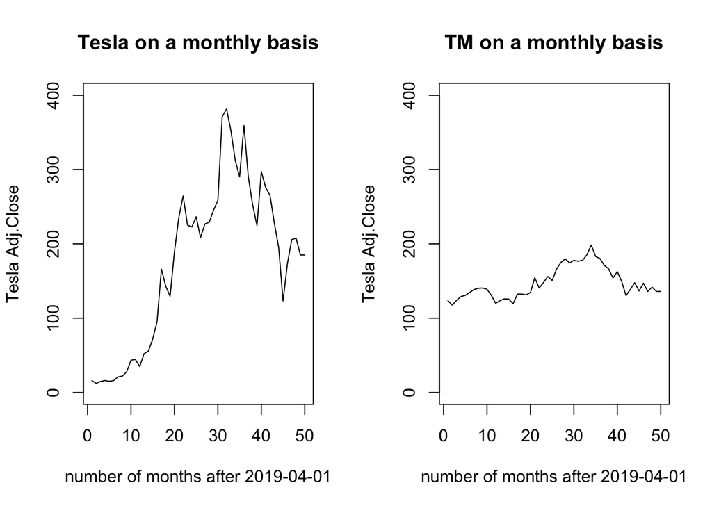

```r
par(mfrow = c(1, 2))
plot(TSLA$Adj.Close, type = "l", xlab = "number of months after 2019-04-01", ylim = c(0, 400), ylab = "Tesla Adj.Close", main = "Tesla on a monthly basis")
abline(v = 110, lwd = 2, col = 'red')
plot(TM$Adj.Close, type = "l", xlab = "number of months after 2019-04-01",ylim = c(0, 400), ylab = "Tesla Adj.Close", main = "TM on a monthly basis")
```

```r
par(mfrow = c(1, 1))
```

##### Clean out columns and add two variables DailyInc and DailyIncRate

```r
Inc = rep(0, 50)
IncRate = rep(0, 50)
for(i in 1:49){
  Inc[i+1] = TSLA$Adj.Close[i+1] - TSLA$Adj.Close[i]
  IncRate[i+1] = Inc[i+1] / TSLA$Adj.Close[i]
}
TSLA_new <- TSLA %>% select(c(Date, Volume, Adj.Close)) %>% mutate(DailyInc = Inc, DailyIncRate = IncRate)
TSLA_new <- TSLA_new[-1,]
Inc = rep(0, 50)
IncRate = rep(0, 50)
for(i in 1:49){
  Inc[i+1] = TM$Adj.Close[i+1] - TM$Adj.Close[i]
  IncRate[i+1] = Inc[i+1] / TM$Adj.Close[i]
}
TM_new <- TM %>% select(c(Date, Volume, Adj.Close)) %>% mutate(DailyInc = Inc, DailyIncRate = IncRate)
TM_new <- TM_new[-1,]
```

##### Comparing TSLA and Toyota: Hypothesis

###### H0: Tesla stock prices increase rate is the same as that of other traditional companies (Toyota) during COVID

###### Ha: Tesla stock prices increase rate is significantly different from that of other traditional companies (Toyota) during COVID

##### Summary Statistics

```r
daily_inc_diff <- sum(TSLA_new$DailyInc) - sum(TM_new$DailyInc)
daily_inc_rate_diff <- sum(TSLA_new$DailyIncRate) - sum(TM_new$DailyIncRate)
daily_inc_diff
```

```
## [1] 156.7273
```

```r
daily_inc_rate_diff
```

```
## [1] 3.460355
```

```r
mean_diff <- mean(TSLA_new$DailyIncRate) - mean(TM_new$DailyIncRate)
mean_diff
```

```
## [1] 0.07061949
```

```r
summary(TSLA_new$DailyIncRate)
```

```
##     Min.  1st Qu.   Median     Mean  3rd Qu.     Max.
## -0.36733 -0.10826  0.02761  0.07425  0.23801  0.74145
```

```r
summary(TM_new$DailyIncRate)
```

```
##      Min.   1st Qu.    Median      Mean   3rd Qu.      Max.
## -0.127737 -0.040440  0.007249  0.003633  0.042451  0.149561
```

##### Conducting a Permutation Test

```r
set.seed(1)
obs_stat <- mean(TSLA_new$DailyIncRate) - mean(TM_new$DailyIncRate)
combined <- c(TSLA_new$DailyIncRate, TM_new$DailyIncRate)
P = 10000
store_mean_diff = rep(0, P)
for (n in 1:P){
  perm <- sample(combined, length(combined), replace = FALSE)
  store_mean_diff[n] = mean(perm[1:49]) - mean(perm[50:98])
}
p_val_perm <- mean(abs(store_mean_diff) >= abs(obs_stat))
p_val_perm
```

```
## [1] 0.0395
```

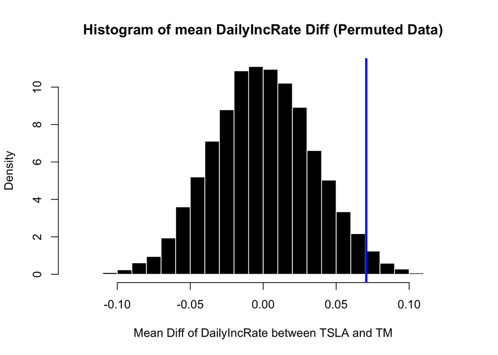

```r
hist(store_mean_diff, breaks = 20, freq = FALSE, col = 'black', border = 'white',
     xlab = 'Mean Diff of DailyIncRate between TSLA and TM',
     main = 'Histogram of mean DailyIncRate Diff (Permuted Data)')
abline(v = obs_stat, col = "blue", lwd = 3)
```

##### Analysis

###### At 5% significance level, a p-value of 0.0395 means that if the Null hypothesis was true, the probability that the difference in mean daily increase rate of TSLA and TM are due to pure chance is 3.95%. Thus, the data provides sufficient evidence to reject the null hypothesis in favor of the alternative hypothesis that: the trends of Tesla and Toyota stock prices differ significantly.

##### Conducting a T-test

```r
t.test(TSLA_new$DailyIncRate, TM_new$DailyIncRate, paired = FALSE)
```

```
##
##  Welch Two Sample t-test
##
## data:  TSLA_new$DailyIncRate and TM_new$DailyIncRate
## t = 2.0743, df = 54.166, p-value = 0.04282
## alternative hypothesis: true difference in means is not equal to 0
## 95 percent confidence interval:
##  0.002367569 0.138871412
## sample estimates:
##  mean of x  mean of y
## 0.07425205 0.00363256
```

##### Introduce new variable

```r
Inc = rep(0, 1008)
IncRate = rep(0, 1008)
for(i in 1:1007){
  Inc[i+1] = TSLA_recent$Adj.Close[i+1] - TSLA_recent$Adj.Close[i]
  IncRate[i+1] = Inc[i+1] / TSLA_recent$Adj.Close[i]
}
TSLA_recent_new <- TSLA_recent %>% select(c(Date, Volume, Adj.Close)) %>% mutate(DailyInc = Inc, DailyIncRate = IncRate)
TSLA_recent_new <- TSLA_recent_new[-1,]
TSLA_recent_new$Date = as.Date(TSLA_recent_new$Date)
TSLA_recent_new$COVID <- ifelse(TSLA_recent_new$Date >= as.Date("2019-03-17") &
                                TSLA_recent_new$Date <= as.Date("2019-12-12"), "Pre-COVID",
                                ifelse(TSLA_recent_new$Date >= as.Date("2019-12-13") &
                                       TSLA_recent_new$Date <= as.Date("2022-09-01"), "COVID", "Post-COVID"))
```

##### Advanced Analysis: modeling Adj.Close against Volume, visualizing using scatterplot color-coded by COVID

```r
library(dplyr)
library(broom)
TSLA_recent_new %>%
  group_by(COVID) %>%
  do(model = lm(Adj.Close ~ Volume, data = .)) %>%
  summarize(period = COVID,
            coefficient = coef(model)[2],
            intercept = coef(model)[1],
            r_squared = summary(model)$r.squared)
```

```
## # A tibble: 3 × 4
##   period     coefficient intercept r_squared
##   <chr>            <dbl>     <dbl>     <dbl>
## 1 COVID         -6.37e-7     290.     0.423
## 2 Post-COVID    -5.78e-7     271.     0.432
## 3 Pre-COVID     -4.45e-9      17.7    0.0124
```

##### Analysis

###### If volume represents the degree that Tesla’s stock is changing hands, signaling investor’s interest in the stock, then examining volume’s correlation to adj. closing price is worthwhile.

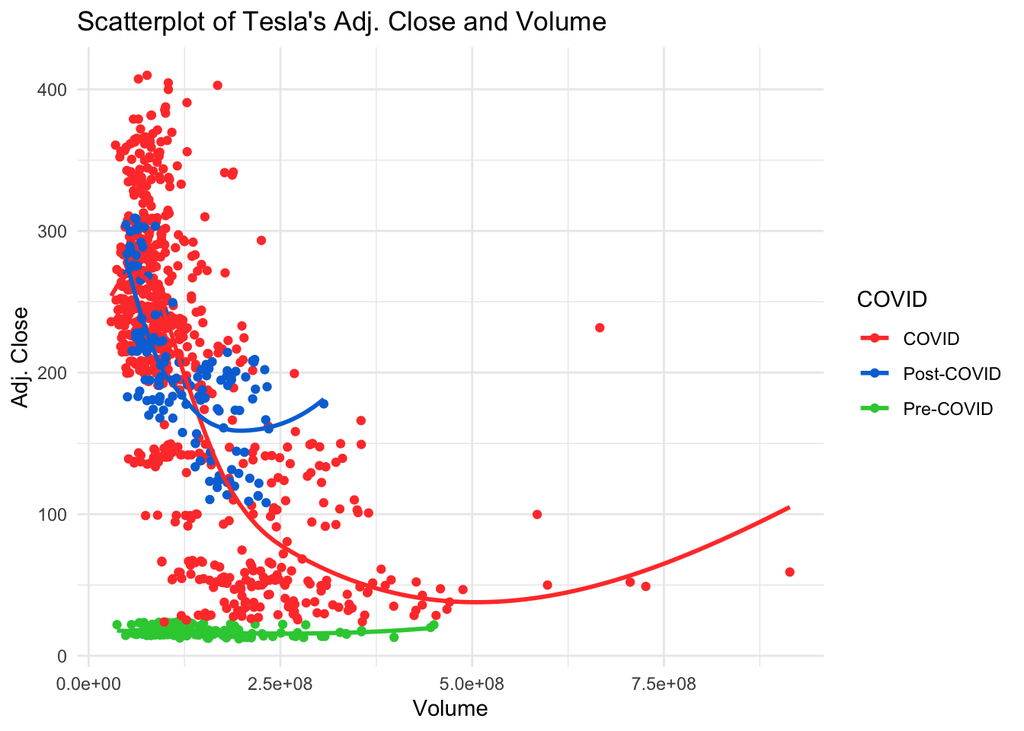

```r
ggplot(TSLA_recent_new, aes(x = Volume, y = Adj.Close, color = COVID)) +
  geom_point() +
  geom_smooth(se = FALSE) +
  labs(title = "Scatterplot of Tesla's Adj. Close and Volume",
       x = "Volume",
       y = "Adj. Close",
       color = "COVID") +
  scale_color_manual(values = c("#FF4136", "#0074D9", "#2ECC40")) +
  theme_minimal()
```

##### Analysis

###### We then ran a non-linear regression model and visualized by adding curves to a color coded scatterplot.

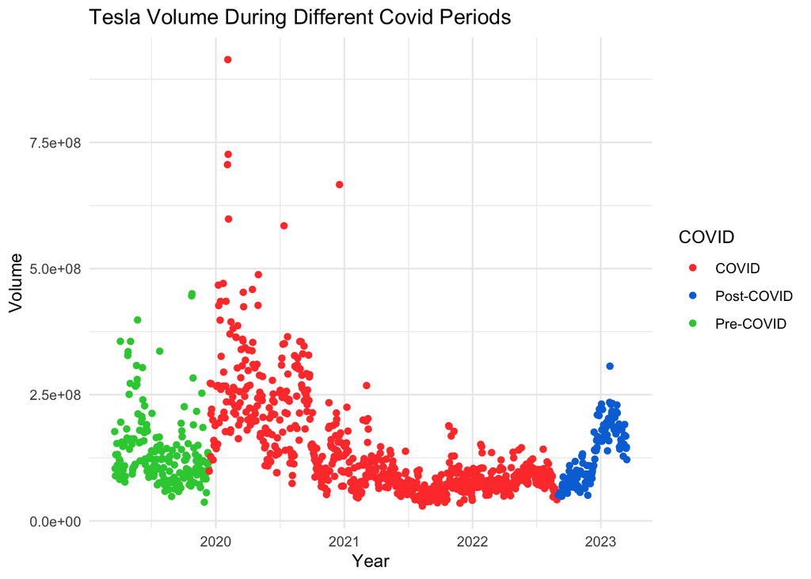

```r
ggplot(TSLA_recent_new, aes(x = Date, y = Volume, color = COVID)) +
  geom_point() +
  labs(x = "Year", y = "Volume") +
  ggtitle("Tesla Volume During Different Covid Periods")+
  scale_color_manual(values = c("#FF4136", "#0074D9", "#2ECC40")) +
  theme_minimal()
```